# Joining tables with `dplyr`

Author

Casey Schine adapted from Emily Malcolm-White

# `nycflights23` dataset

```r
#LOAD PACKAGES
library(tidyverse)

#LOAD DATA
library(nycflights23)
data("flights")
```

`nycflights23` contains information about all 435352 flights departing NYC in 2023.

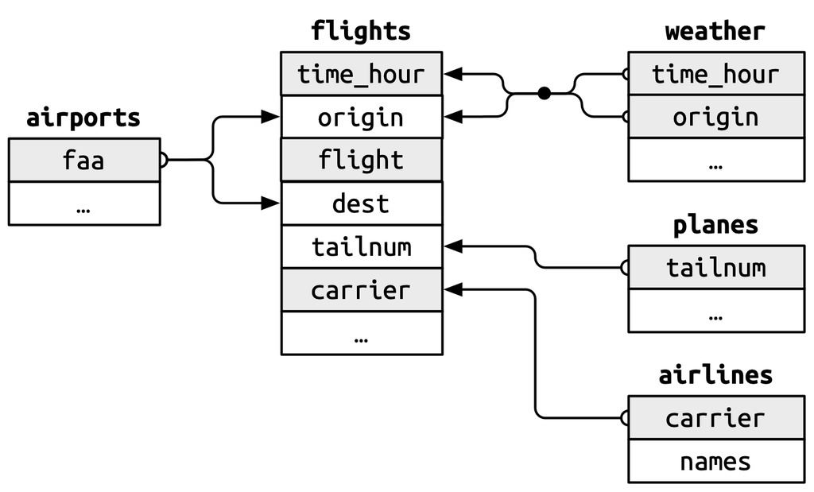

# Join dataframes

## Matching key variable names

```r
data("airlines")
```

We want to have all this information in one data frame instead of two separate data frames.

The variable `carrier` in `flights` match the variable `carrier` in the `airlines` dataset – this is our *key variable*. In this case, they have the same name, but this doesn’t necessarily have to be true.

```r
# look at carrier variable in airlines data
# open data in viewer

# look at carrier variable in flights data
# Data set is too long to just click on it and get a good look, so what can we do here?
flights |>
  distinct(carrier)
```

```
# A tibble: 14 × 1
   carrier
   <chr>
 1 UA
 2 DL
 3 B6
 4 AA
 5 NK
 6 WN
 7 AS
 8 YX
 9 9E
10 HA
11 G4
12 MQ
13 OO
14 F9
```

**Different Types of Joins**

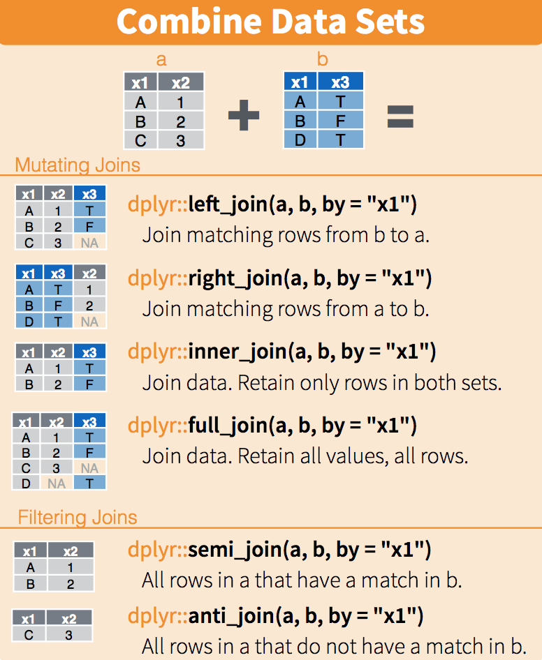

Credit: RStudio

There are several different kinds of joins. Which one you choose will depend on what you are trying to accomplish.

```r
# use "key" variable to join the two data sets
# ?join to look at the help documentation
flights_joined <- flights |>
  left_join(airlines, by="carrier")

# check join
flights_joined |>
  distinct(name)
```

```
# A tibble: 14 × 1
   name
   <chr>
 1 United Air Lines Inc.
 2 Delta Air Lines Inc.
 3 JetBlue Airways
 4 American Airlines Inc.
 5 Spirit Air Lines
 6 Southwest Airlines Co.
 7 Alaska Airlines Inc.
 8 Republic Airline
 9 Endeavor Air Inc.
10 Hawaiian Airlines Inc.
11 Allegiant Air
12 Envoy Air
13 SkyWest Airlines Inc.
14 Frontier Airlines Inc.
```

## Different key variable names

```r
data("airports")
```

In `airports` the airport code is in `faa`, whereas in `flights` the airport codes are in `origin` and `dest`.

```r
# look at airports and flights data to find where airport variables are stored


# join airport to flights data

flights_with_airport_names <- flights |>
  left_join(airports, by=c("dest"="faa"))

# check the join
```

### In Groups

In groups, construct the chain of pipe operators |> that computes the number of flights from NYC to each destination, but also includes information about each destination airport. Start with the first part, compute the number of flights from NYC to each destination, and then do your join.

```r
# In groups!!!

named_destinations <- flights |>
  group_by(dest) |>
  summarize(num_flights=n()) |>
  left_join(airports, by=c("dest"="faa"))
```

Now, make a kable table with the top 5 airports with airport name in the first column, the airport code in the next column, and the number of flights to that airport from NYC in the third column.

```r
library(kableExtra)

named_destinations |>
  arrange(desc(num_flights)) |>
  slice(1:5) |>
  select(name, dest, num_flights) |>
  kbl() |>
  kable_styling()
```

| name | dest | num_flights |
| --- | --- | --- |
| General Edward Lawrence Logan International Airport | BOS | 19036 |
| Chicago O'Hare International Airport | ORD | 18200 |
| Orlando International Airport | MCO | 17756 |
| Hartsfield Jackson Atlanta International Airport | ATL | 17570 |
| Miami International Airport | MIA | 16076 |

## Multiple Key variables

In order to join the flights and weather data frames, we need more than one key variable: `year`, `month`, `day`, `hour`, and `origin`. This is because the combination of these 5 variables act to uniquely identify each observational unit in the weather data frame: hourly weather recordings at each of the 3 NYC airports.

```r
data("weather")
```

```r
flights_weather_joined <- flights |>
  left_join(weather, by = c("year", "month", "day", "hour", "origin"))
```

### In groups

In groups, join the `weather` data to the `flights` data with an `inner_join()`.

```r
flights_weather_joined_inner <- flights |>
  inner_join(weather, by = c("year", "month", "day", "hour", "origin"))
```

What is the difference between the result with a `left_join()` and an `inner_join()`? How many rows different are the resulting datasets? Which rows did you lose? Why did you lose them? Which is the better join in this case? *Hint: Look at the table at the beginning with different kinds of joins*

```r
flights_weather_joined_inner <- flights |>
  anti_join(weather, by = c("year", "month", "day", "hour", "origin"))
```

## Why is this useful?

Updating labels:

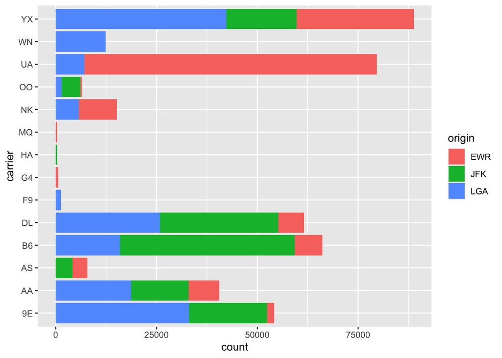

```r
# make bar plot (using geom_bar) with y as carrier and fill as origin
# use original flights dataset

flights %>%
ggplot(aes(x = carrier, fill = origin)) +
  geom_bar() +
  coord_flip()
```

### In groups

Now make the same figure as above, but use joining to replace the origin airport code with the origin airport name using the `aiports` dataset and the carrier code with the carrier name using the `airlines` dataset.

*Hint: if doing it all at once seems overwhelming do it one piece at a time and then put all of the pieces together. First, do the airports join. Then do the airlines join. And then put them together.*

[figure not shown]

```r
# now do the same thing but join the airports and airlines datasets to the flights dataset

flights %>%
  inner_join(airports, by = c("origin" = "faa")) %>%
  rename(origin_airport = name) %>%
  inner_join(airlines, by = c("carrier")) %>%
  rename(carrier_name= name) %>%
ggplot(mapping = aes(y = carrier_name, fill = origin_airport)) +
  geom_bar() +
  coord_flip()
```

Exploring relationships between variables in separate tables:

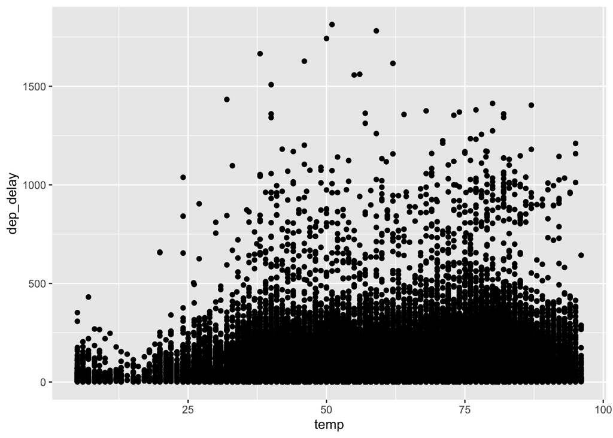

```r
# look at the relationship between temp and dep_delay in the flights and weather joined dataset (filter for dep_delay > 0)
flights_weather_joined %>%
  filter(dep_delay >0) %>%
  ggplot(aes(x=temp, y=dep_delay)) +
  geom_point()
```

```r
# add color by another variable
```